# Milestone Report: Exploratory Analysis, Algorithm and App Goals

Kim Kirk

11/15/2021

## Exploratory Analysis: Data downloaded and loaded into R Studio

Data was downloaded and loaded into R Studio. Systematic sampling was performed on the data to reduce the size of the data set and still provide a representative sample of the data.

```r
library(readtext)
library(tidytext)
library(dplyr)
library(ggplot2)
library(cld2)
library(cld3)
library(readxl)
library(stringr)
library(R.utils)
library(lexicon)
library(qdap)
library(tm)
library(magrittr)
library(textclean)
library(hunspell)
```

```
#get the sample from each corpus
sample_corpus()
sample_corpus("corpusSampleFileNews.txt", "news")
sample_corpus("corpusSampleFileBlogs.txt", "blogs")


#put all samples into one data frame
allSamplesDataFrame <- readtext(paste(getwd(), 'final', 'en_US', 'Samples', sep = "/"), text_field = 1, encoding = "UTF-8")
```

## Exporatory Analysis: Summaries

Word counts, line counts, and data tables were created to generate summaries of the three word files.

```r
#tokenize the dataframe
    #tokenize by word
tokenize_this <- function(a_file){
    tokenized_dataframe <- a_file %>% unnest_tokens(token, text, strip_punct = TRUE)
    return (tokenized_dataframe)

}

allSamplesTokenized <- tokenize_this(allSamplesDataFrame)



# basic summaries of the three files? Word counts, line counts and basic data tables
#find the frequency of words in the text: create relative and cumulative frequency table
frequencyTables <- function(x = allSamplesTokenized) {
    x %>% count(token, sort = TRUE) %>% arrange(n) %>% mutate(rel_freq = n/sum(n), cum_freq = cumsum(rel_freq))
}


#word counts and line count summaries
summaries <- function(corpus_name) {
    setwd("~/R Projects/Final Work for Capstone Project/final/en_US/Samples")
    #line count
    print("Line count: ")
    print(countLines(corpus_name))
    #word count
    print("Word count: ")
    print(str(allSamplesTokenized[allSamplesTokenized$doc_id == corpus_name,2]))
}

summaries("en_Blogs_corpusSampleFile.txt")
```

```
## [1] "Line count: "
## [1] 16287
## attr(,"lastLineHasNewline")
## [1] TRUE
## [1] "Word count: "
##  chr [1:676825] "in" "the" "years" "thereafter" "most" "of" "the" "oil" "fields" ...
## NULL
```

```r
summaries("en_News_corpusSampleFile.txt")
```

```
## [1] "Line count: "
## [1] 16295
## attr(,"lastLineHasNewline")
## [1] TRUE
## [1] "Word count: "
##  chr [1:556592] "he" "wasn't" "home" "alone" "apparently" "translation" "the" ...
## NULL
```

```r
summaries("en_Twitter_corpusSampleFile.txt")
```

```
## [1] "Line count: "
## [1] 16472
## attr(,"lastLineHasNewline")
## [1] TRUE
## [1] "Word count: "
##  chr [1:210966] "how" "are" "you" "btw" "thanks" "for" "the" "rt" "you" "gonna" ...
## NULL
```

```r
#data tables
uniGramFrequencyTable <- frequencyTables()
```

## Exploratory Analysis: Plots

Basic plots were created to further illustrate the nature of the data and uncover interesting findings.

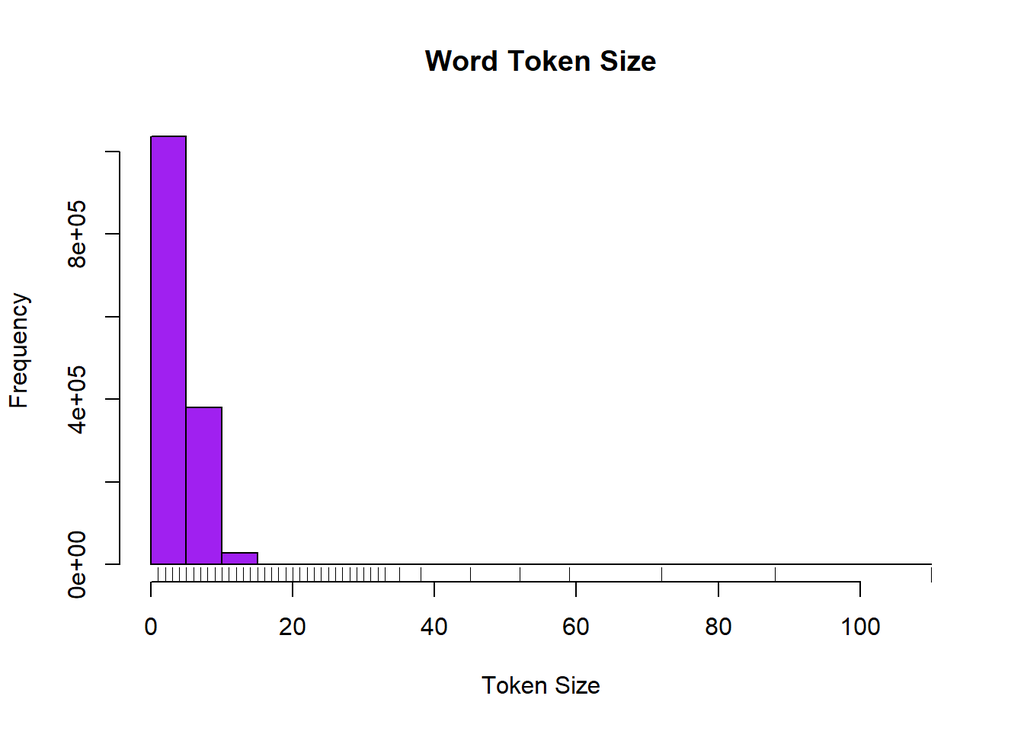

```r
#basic plots, such as histograms to illustrate features of the data
#create a histogram to see distribution of tokens by length
hist(sapply(allSamplesTokenized$token, nchar), col = "purple", xlab = "Token Size", main = "Word Token Size" )
#add lines to more easily identify value points on histogram
rug(sapply(allSamplesTokenized$token, nchar), side = 1)
```

```r
#exploring the dimensions of the data frame
glimpse(allSamplesTokenized)
```

```
## Rows: 1,444,383
## Columns: 2
## $ doc_id <chr> "en_Blogs_corpusSampleFile.txt", "en_Blogs_corpusSampleFile.txt", "en_B~
## $ token  <chr> "in", "the", "years", "thereafter", "most", "of", "the", "oil", "fields~
```

```r
#getting a summary of the data frame
summary(allSamplesTokenized$token)
```

```
##    Length     Class      Mode
##   1444383 character character
```

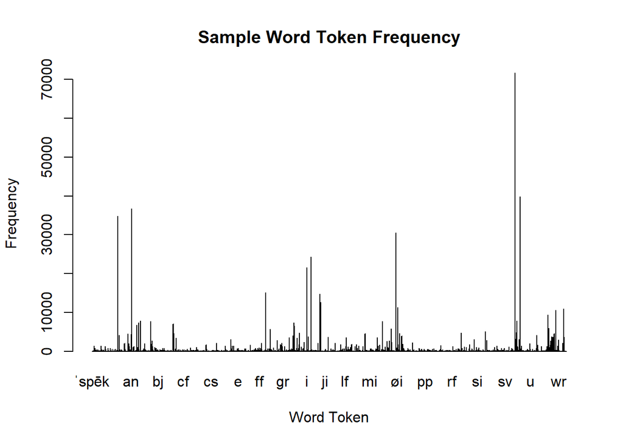

```r
#visualize the tokens and their frequency in the data frame
barplot(table(allSamplesTokenized$token), col = "wheat", xlab = "Word Token", ylab = "Frequency", main = "Sample Word Token Frequency")
```

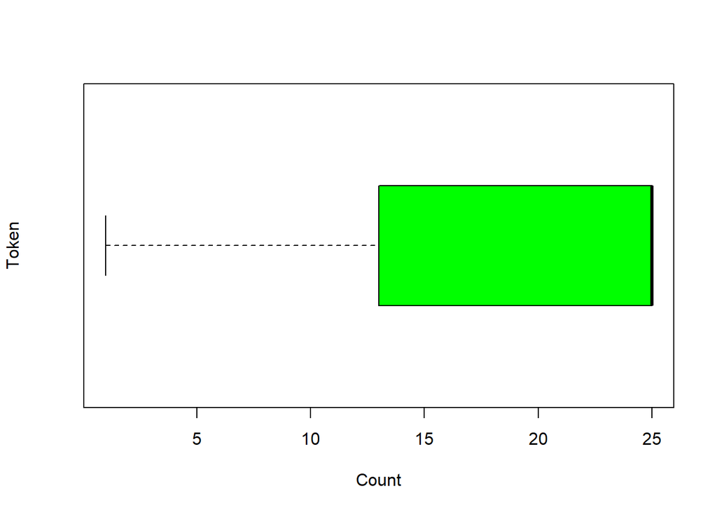

```r
#check for outliers
#create a box plot to see outliers
    #check how many outliers first
    #if small, delete outliers
boxplot(nchar(allSamplesTokenized$token ~ allSamplesTokenized$token), xlab = 'Count',
        ylab = 'Token', col = 'green', horizontal = TRUE)
```

```r
#it looks like no outliers in the data
    #however the data is very heavily skewed with the median, 3rd quartile, and max value being equal; this means the data is not normally distributed and I will need to likely use a non-parametric test
```

## Algorithm and App Goals: Model Prediction and Deployment to Shiny Apps Cloud

The objective is to determine the next word based on previous word(s) used. A Markov Chain will fit this purpose well. A Markov Chain model should be able to determine the next word the user will type.

After the machine learning model is trained, I will use it in a Shiny App and deploy it to the cloud where users can type in their word of choice and the model will predict the next word they will type.